# Portfoliomanagement and Financial Analysis - Assignment 4

Submit until Monday 2019-10-07, 13:00

Lastname, Surname

```r
pacman::p_load(tidyverse,tidyquant,PortfolioAnalytics,nloptr,tsibble,matrixcalc,Matrix,timetk,xts)
```

**Please** remember to put your assignment solutions in `rmd` format using **many** chunks and putting readable text in between, similar to my examples given in Research Methods and Assignment 1! Also, each student has to select his own set of 10 stocks having data available as of `2000-01-01`. Select by Sharpe-ratio, dominance or any other method (e.g. matching your first name).

*For all exercises: Please use the Assignment-Forum to post your questions, I will try my best to help you along!*

*## Exercise 4: Single Index-Model*

*Now we are going to estimate the Portfolio Input Parameters with the Single-Index Model. Use your ten assets and additionally choose the S&P500 as index (same returns etc).*

*a) Regress all stocks on the index. Show alpha, beta and residual variance. Calculate systematic and firm-specific risk. Are there any significant alphas? (You should double check with the appropriate `PerformanceAnalytics` Functions)*

*b) Extract the betas and calculate systematic and unsystematic risk, derive the whole covariance matrix. To do this you can use *CH15_Factor_Modfels_for_Asset_Returns.pdf (15.3.1)* and the code implemented in the function sharpeFactorEstimator that you find [here](http://financewithr.blogspot.com/2013/06/portfolio-optimization-using-single.html) (please do not just copy everything, but try to understand what you are doing, e.g. check why and if G.hat has the same values as found by the multivariate regression).*

*c) Now use the *custom-moments* functions from Exercise 2 to implement the single-factor model into the portfolio optimization framework and plot the efficient frontier using the parameters estimated by the single factor model next to the EF of the full-covariance model. Calculate MVP, TP etc. and work out the differences in weights, portfolio return and portfolio risk.*

### Get the packages

Now we are going to estimate the Portfolio Input Parameters with the Single-Index Model. Use your ten assets and additionally choose the S&P500 as index (same returns etc).

```r
stockselection_4 <- c("T","WMT", "MSFT","BAC","PG") %>% # My specific stocks
  c("^GSPC")                                            # My specifc index
stockselection_4
```

```
[1] "T"     "WMT"   "MSFT"  "BAC"   "PG"    "^GSPC"
```

```r
#Get the prices of the stocks
stock.prices_4 <- stockselection_4 %>%
  tq_get(get  = "stock.prices", from = "2015-07-06",to = Sys.Date( )) %>% #First trade day of KHC
  group_by(symbol)

# Output the first two entries of each stock!
stock.prices_4 %>% slice(1:2)
```

| symbol | date | open | high | low | close | volume | adjusted |
| --- | --- | --- | --- | --- | --- | --- | --- |
| ^GSPC | 2015-07-06 | 2073.95 | 2078.61 | 2058.40 | 2068.76 | 3486360000 | 2068.76001 |
| ^GSPC | 2015-07-07 | 2069.52 | 2083.74 | 2044.02 | 2081.34 | 4458660000 | 2081.34009 |
| BAC | 2015-07-06 | 16.78 | 17.01 | 16.71 | 16.94 | 58726900 | 15.35557 |
| BAC | 2015-07-07 | 16.90 | 16.93 | 16.34 | 16.69 | 115450500 | 15.12896 |
| MSFT | 2015-07-06 | 43.96 | 44.48 | 43.95 | 44.39 | 23034000 | 40.07714 |
| MSFT | 2015-07-07 | 44.34 | 44.49 | 43.32 | 44.30 | 36435800 | 39.99589 |
| PG | 2015-07-06 | 79.61 | 80.22 | 79.50 | 80.05 | 6601200 | 68.11373 |
| PG | 2015-07-07 | 80.06 | 81.83 | 80.06 | 81.72 | 11690400 | 69.53471 |
| T | 2015-07-06 | 35.60 | 35.66 | 35.47 | 35.61 | 25640300 | 26.10547 |
| T | 2015-07-07 | 35.79 | 35.85 | 35.37 | 35.77 | 27143900 | 26.22277 |

[output cut: 2 more lines]

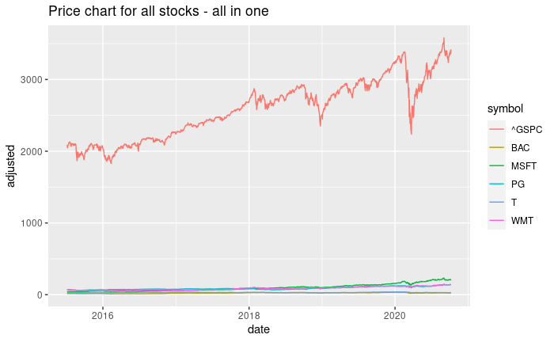

```r
stock.prices_4 %>%
  ggplot(aes(x = date, y = adjusted, color = symbol)) +
  geom_line() +
  ggtitle("Price chart for all stocks - all in one")
```

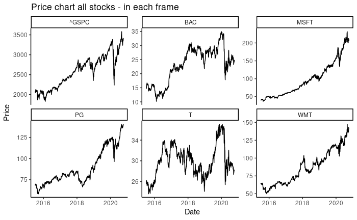

```r
# Plotting the stock prices in each frame
stock.prices_4 %>%
  ggplot(aes(x = date, y = adjusted)) +
  geom_line() +
  facet_wrap(~symbol, scales = "free_y") +
  theme_classic() +
  labs(x = "Date", y = "Price") +
  ggtitle("Price chart all stocks - in each frame")
```

```r
NA
NA
```

```r
# Create monthly returns by the tq_transmute() = adds new variables to an existing tibble;
stock.returns.monthly_4 <- stock.prices_4 %>%
  tq_transmute(select = adjusted,
               mutate_fun = periodReturn,
               period="monthly",
               type="arithmetic",
               col_rename = "Stock.returns")

# Output the first two entries of each stock!
stock.returns.monthly_4 %>% slice(1:2)
```

| symbol | date | Stock.returns |
| --- | --- | --- |
| ^GSPC | 2015-07-31 | 0.01695706 |
| ^GSPC | 2015-08-31 | -0.06258082 |
| BAC | 2015-07-31 | 0.05549001 |
| BAC | 2015-08-31 | -0.08612998 |
| MSFT | 2015-07-31 | 0.05203882 |
| MSFT | 2015-08-31 | -0.06194910 |
| PG | 2015-07-31 | -0.03400332 |
| PG | 2015-08-31 | -0.07861805 |
| T | 2015-07-31 | -0.01144204 |
| T | 2015-08-31 | -0.04432933 |

[output cut: 2 more lines]

```r
# Make 10 columns (each for every stock) with the simple returns from adjusted prices and convert to xts
stock.returns.monthly_xts_4 <- pivot_wider(stock.returns.monthly_4,
                                                names_from = symbol,
                                                values_from = c(Stock.returns))%>%
   tk_xts(date_var = date, silent = TRUE)

# Output the first entries (simple returns from adjusted prices) of each stock!
stock.returns.monthly_xts_4[1]
```

```
                     T         WMT       MSFT        BAC          PG      ^GSPC
2015-07-31 -0.01144204 -0.00758285 0.05203882 0.05549001 -0.03400332 0.01695706
```

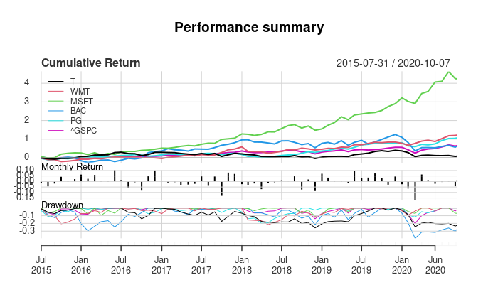

```r
# Plotting a performance summary chart
charts.PerformanceSummary(stock.returns.monthly_xts_4,
                          main="Performance summary")
```

1. Regress all stocks on the index. Show alpha, beta and residual variance. Calculate systematic and firm-specific risk. Are there any significant alphas? (You should double check with the appropriate `PerformanceAnalytics` Functions)

```r
# Presettings
n <- length(stockselection_4)

#Regress all stocks on the index
alpha.Stocks <- CAPM.alpha(Ra = stock.returns.monthly_xts_4[,-n], Rb = stock.returns.monthly_xts_4[,n], Rf = 0)
beta.Stocks <- CAPM.beta(Ra = stock.returns.monthly_xts_4[,-n], Rb = stock.returns.monthly_xts_4[,n], Rf = 0)
StdDev.Index <- StdDev(R = stock.returns.monthly_xts_4[,n],
                   clean = "none",
                   method = "pearson")

lm(stock.returns.monthly_xts_4[,-n] ~ stock.returns.monthly_xts_4[,n])
```

```
Call:
lm(formula = stock.returns.monthly_xts_4[, -n] ~ stock.returns.monthly_xts_4[,
    n])

Coefficients:
                                  T          WMT        MSFT       BAC        PG
(Intercept)                       -0.003431   0.010944   0.019510  -0.002205   0.008307
stock.returns.monthly_xts_4[, n]   0.690411   0.327395   0.929832   1.533656   0.456441
```

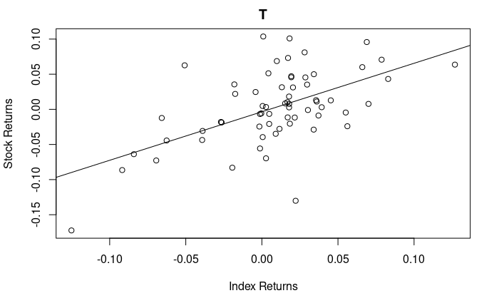

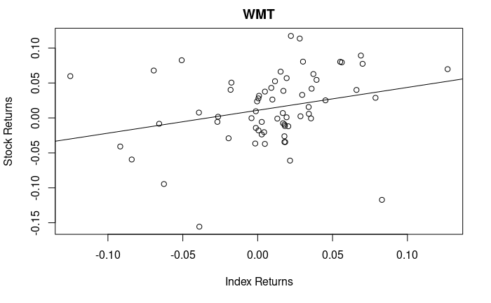

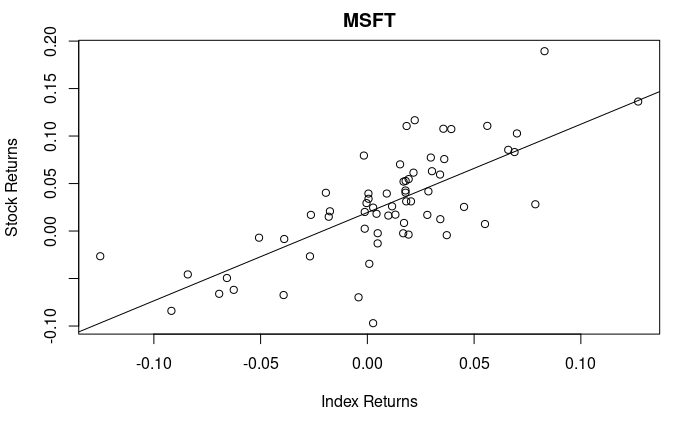

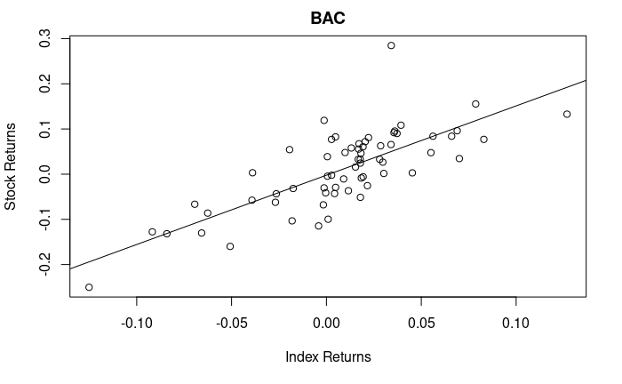

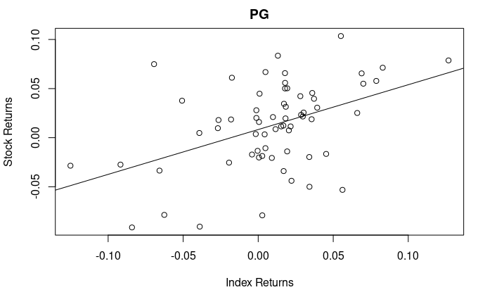

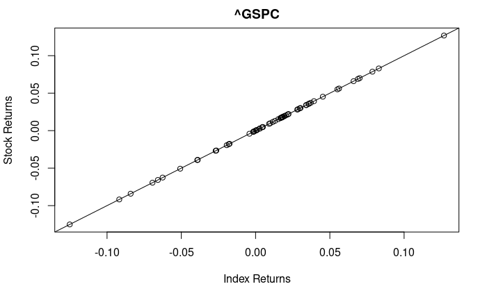

```r
for(i in 1:n) {
plot.default(x = stock.returns.monthly_xts_4[, n],
            y = stock.returns.monthly_xts_4[, i],
            main = stockselection_4[i],
            xlab = "Index Returns",
            ylab = "Stock Returns",
            abline(lm(stock.returns.monthly_xts_4[, i] ~ stock.returns.monthly_xts_4[, n])))
}
```

```r
#Calculate systematic (Market-Specific) Risk by mulitplying Variance (StdDev^2) of the S&P500 and the Beta^2 of each stock
sys.risk <- SystematicRisk(Ra = stock.returns.monthly_xts_4[,-n], Rb = stock.returns.monthly_xts_4[,n], Rf = 0)
sys.risk
```

```
                                          T        WMT      MSFT       BAC         PG
Systematic Risk to ^GSPC (Rf = 0) 0.1023698 0.04854408 0.1378696 0.2274009 0.06767823
```

```r
#Calculate Firm-specific Risk / Residual Variance
firm.specific.risk <- SpecificRisk(Ra = stock.returns.monthly_xts_4[,-n], Rb = stock.returns.monthly_xts_4[,n], Rf = 0)
firm.specific.risk
```

```
                         T       WMT      MSFT       BAC        PG
Specific Risk =  0.1492702 0.1706623 0.1336803 0.1926448 0.1325658
```

```r
#Summary
summary.SFM <- table.SFM(Ra = stock.returns.monthly_xts_4[,-n], Rb = stock.returns.monthly_xts_4[,n], scale = NA, Rf = 0, digits = 6)
summary.SFM
```

|  | T to ^GSPC | WMT to ^GSPC | MSFT to ^GSPC | BAC to ^GSPC | PG to ^GSPC |
| --- | --- | --- | --- | --- | --- |
| Alpha | -0.003431 | 0.010944 | 0.019510 | -0.002205 | 0.008307 |
| Beta | 0.690411 | 0.327395 | 0.929832 | 1.533656 | 0.456441 |
| Beta+ | 0.472870 | 0.438716 | 1.134874 | 1.202569 | 0.579994 |
| Beta- | 0.931717 | -0.010909 | 0.760592 | 1.538551 | 0.450362 |
| R-squared | 0.316462 | 0.073769 | 0.511489 | 0.578345 | 0.204179 |
| Annualized Alpha | -0.040401 | 0.139528 | 0.260955 | -0.026146 | 0.104372 |
| Correlation | 0.562549 | 0.271605 | 0.715185 | 0.760490 | 0.451862 |
| Correlation p-value | 0.000001 | 0.029931 | 0.000000 | 0.000000 | 0.000178 |
| Tracking Error | 0.157297 | 0.198831 | 0.135138 | 0.209672 | 0.156039 |
| Active Premium | -0.083691 | 0.061921 | 0.265171 | -0.004101 | 0.046901 |

[output cut: 2 more lines]

```r
NA
```

2. Extract the betas and calculate systematic and unsystematic risk, derive the whole covariance matrix. To do this you can use *CH15_Factor_Models_for_Asset_Returns.pdf (15.3.1)* and the code implemented in the function sharpeFactorEstimator that you find [here](http://financewithr.blogspot.com/2013/06/portfolio-optimization-using-single.html) (please do not just copy everything, but try to understand what you are doing, e.g. check why and if G.hat has the same values as found by the multivariate regression).

```r
#Calculate Beta of Portfolio by average each stocks beta
beta.portfolio <- mean(beta.Stocks)
beta.portfolio
```

```
[1] 0.7875468
```

```r
#Calculate systematic (Market-Specific) Risk of portfolio
sys.risk.portfolio <- mean(sys.risk)
sys.risk.portfolio
```

```
[1] 0.1167725
```

```r
#Calculate unsystematic risk by calculating the mean of the firm-specific risk
unsys.risk.portfolio <- mean(firm.specific.risk)
unsys.risk.portfolio
```

```
[1] 0.1557647
```

```r
#Calculate Covariance Matrix
stock.returns.monthly_data <- as.data.frame((stock.returns.monthly_xts_4))
head(stock.returns.monthly_data)
```

|  | T | WMT | MSFT | BAC | PG | ^GSPC |
| --- | --- | --- | --- | --- | --- | --- |
| 2015-07-31 | -0.011442045 | -0.007582850 | 0.05203882 | 0.05549001 | -0.03400332 | 0.0169570554 |
| 2015-08-31 | -0.044329330 | -0.094581869 | -0.06194910 | -0.08612998 | -0.07861805 | -0.0625808182 |
| 2015-09-30 | -0.018674823 | 0.001699312 | 0.01700377 | -0.04344170 | 0.01797109 | -0.0264428316 |
| 2015-10-30 | 0.043265440 | -0.117211495 | 0.18933564 | 0.07702189 | 0.07126051 | 0.0829831178 |
| 2015-11-30 | 0.004774821 | 0.027952403 | 0.03944428 | 0.03873643 | -0.02016241 | 0.0005048693 |
| 2015-12-31 | 0.021977948 | 0.050534539 | 0.02079122 | -0.03170509 | 0.06106373 | -0.0175301852 |

```r
returns <- as.timeSeries(stock.returns.monthly_data[,-n])
factors <- as.vector(as.timeSeries(stock.returns.monthly_data)[,n])

names(data)
```

```r
data <- returns
attr(data, "factors") <- factors
nScenarios <- nrow(data)

X.mat <- cbind(rep(1, times=nScenarios), factors)

G.hat <- solve(qr(X.mat), data) #G.hat is alpha

beta.hat <- G.hat[2, ] #is beta

eps.hat <- data - X.mat %*% G.hat

diagD.hat <- diag(crossprod(eps.hat) / (nScenarios-2))

cov.si = var(factors)*(beta.hat%o%beta.hat) + diag(diagD.hat)

cov.si
```

```
                T          WMT         MSFT          BAC           PG
T    0.0027899932 0.0004141206 0.0011761404 0.0019399152 0.0005773505
WMT  0.0004141206 0.0027018081 0.0005577295 0.0009199139 0.0002737814
MSFT 0.0011761404 0.0005577295 0.0031212443 0.0026126397 0.0007775643
BAC  0.0019399152 0.0009199139 0.0026126397 0.0075016954 0.0012825074
PG   0.0005773505 0.0002737814 0.0007775643 0.0012825074 0.0018934113
```

3. Now use the *custom-moments* functions from Exercise 2 to implement the single-factor model into the portfolo optimization framework and plot the efficient frontier using the parameters estimated by the single factor model next to the EF of the full-covariance model.

```r
#Function to implement single-factor model into the portfolio optimization framework

returns <- as.timeSeries(stock.returns.monthly_xts_4)
names(data)
data <- returns[, -c(n)]
factors <- returns[, n]
attr(data, "factors") <- factors
# Sharpe's Single Index Factor Model:
sharpeFactorEstimator <-
function(x, spec=NULL, ...)
{
    # Sharpe Single Index Model:
    data <- getDataPart(x)
    factors <- attr(x, "factors")
    nScenarios <- nrow(data)
    X.mat <- cbind(rep(1, times=nScenarios), factors)
    G.hat <- solve(qr(X.mat), data)
    beta.hat <- G.hat[2, ]
    eps.hat <- data - X.mat %*% G.hat
    diagD.hat <- diag(crossprod(eps.hat) / (nScenarios-2))
    mu <- G.hat[1, ] + G.hat[2, ] * colMeans(factors)
    Sigma <- var(factors)[[1]] * (beta.hat %o% beta.hat) + diag(diagD.hat)

    # Return Value:
    list(mu = mu, Sigma = Sigma)
}
spec <- portfolioSpec()
setEstimator(spec) <- "sharpeFactorEstimator"
sharpe <- portfolioFrontier(data, spec)

#Chart the efficient frontier using the parameters estimated by the single factor model
sharpe_1 <- portfolioFrontier(data)
tailoredFrontierPlot(sharpe_1)
points(frontierPoints(sharpe), col = "steelblue")


#Chart Efficient Frontier minimum variance
chart.EfficientFrontier(prt_eff_minv, match.col="StdDev", type="b", rf=NULL, pch.assets = 1)
```

[output not shown]

```r
#weights, portfolio return and portfolio risk of MVP
opt.sd.minv.shrink
```

[output not shown]